# (Effects of Loan Characteristics on Their Status)

## by (Mosta Ashour)

## Investigation Overview

> In this investigation, I wanted to look at the characteristics of loans that could be used to predict their Status whether Completed or Defaulted. The main focus was on the loan term, original loan amount, Borrower's Annual Percentage Rate, and borrower's stated monthly income.

## Dataset Overview

> The dataset consisted of Loan Status and attributes of 113,937 loans. The attributes included loan term, original loan amount, Borrower's Annual Percentage Rate, and much more with 81 variables. 871 data points were removed from the analysis due to duplicates listingKey column which the column should be unique values.

## (Distribution of LoanStatus)

> Loan Status in the dataset take on a variety of Loan Status like `Current` with the highest frequenc Status, `Completed` Status with 33.4%, `Chargedoff`, `Defaulted` and `Past Due` Loans. Plotting a bar for these categorical values, then a pie chart to focus in these two types of Status **'Completed', 'Defaulted'**.

[figure not shown]

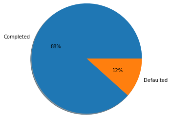

## (Distribution of IncomeRange)

> Interestingly, it looks like most of the borrowers asking for loan in the middle range of income between 25k and 75k, but still 75k+ still have a range of borrwers. Under 25k borrowers are less to ask for Laons.

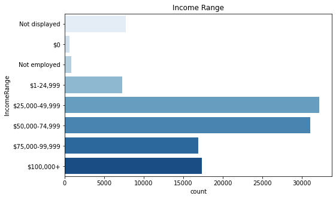

## (Distribution of BorrowerAPR)

> The distribution of BorrowerAPR tend to be symmetric, and roughly multimodal. A small peak centered at 0.1, a large peak contered at 0.18, 0.2 and 0.3. Finally the largest peak centerd at 0.37.

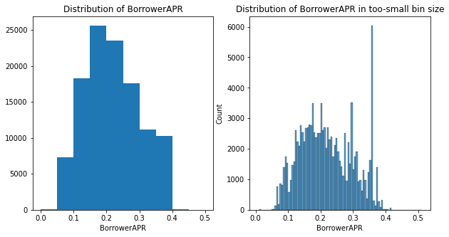

## (LoanStatus vs. term)

> We can see that borrowers with one year Term are almost all Completed them Loans without Defaulted with percentage of 99.32%. Three years term was the worst with 12.36% of Defaulted.

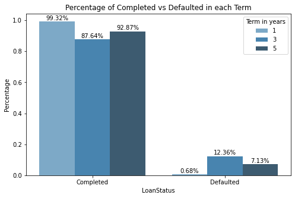

## (LoanStatus vs. BorrowerAPR)

> - Interestingly, Defaulted borrowers had a higher median in the BorrowerAPR!
> - First and third quartile shows that the more interest rate is high the less borrowers Complete the Loan.
> - Current Status tend to have BorrowerAPR in the range of 0.18 to 0.22, it's a new range of BorrowerAPR between Defaulted and Completed Loans median.

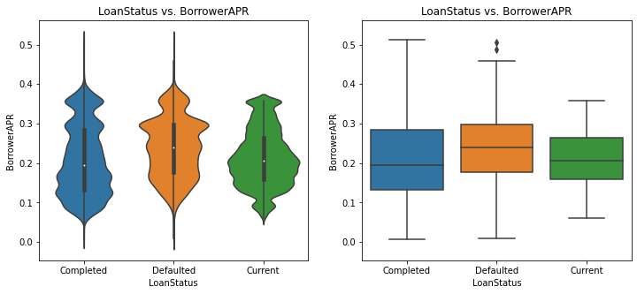

## (LoanStatus vs. StatedMonthlyIncome by Time)

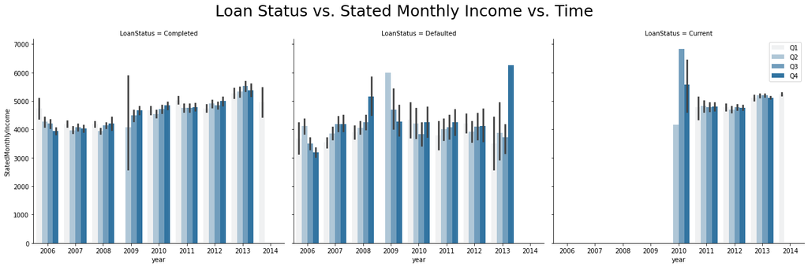

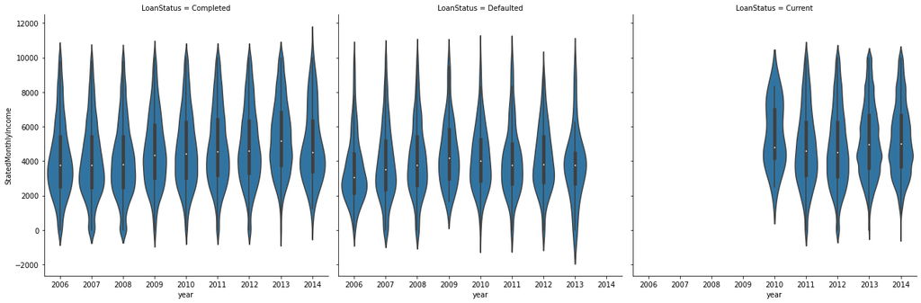

## (LoanStatus vs. LoanOriginalAmount by Term)

> - For shorter loan 1 year term the Loan Status "Current" had the highest Loan Original Amount, Defaulted was the lowest. For 3 and 5 years Term, borrowers had a higher range of Loan amount, thought the longer term, the bigger amound of Loan. Current borrowers seems to get lower Loan term than longer.

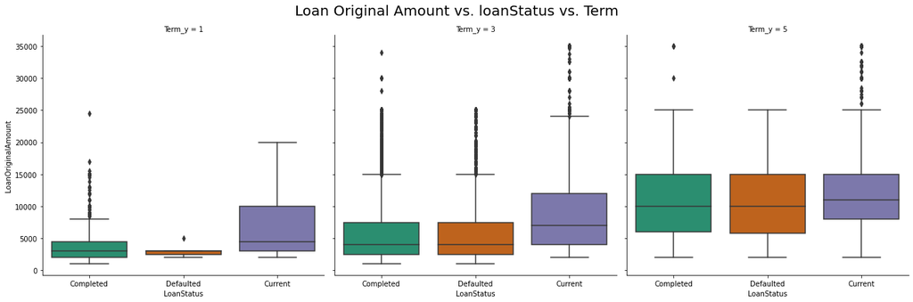